# Does early planting of wheat affect mean yield and risk? Just-Pope residual based and Antle moments production risk analysis

Author

Maxwell Mkondiwa

# 1 Introduction

This notebook provides a reproducible workflow for Just-Pope production function and moments based approach to production risk analysis.

We use data collected under the CSISA-KVK agronomic trials.

```r
CSISA_KVKestim=read.csv("CSISA_KVK_wheat_public_cleaned.csv")

#load("CSISA_KVK_Public_Workspace.RData")

table(CSISA_KVKestim$SowingSchedule)
```

```
 T1  T2  T3  T4  T5
408 858 806 881 695
```

```r
#CSISA_KVKestim$SowingSchedule=ordered(CSISA_KVKestim$SowingSchedule,levels=c("T5","T4","T3","T2","T1"))

#Create dummies for some categorical variables
library(fastDummies)
CSISA_KVKestim <- fastDummies::dummy_cols(CSISA_KVKestim, select_columns =c("SowingSchedule","VarietyClass","SoilType","CropEstablishment","Year","District"))

# Make calculations on nitrogen, phosphurus, potassium applied

## Nitrogen
CSISA_KVKestim$GradeNPKN[CSISA_KVKestim$GradeNPK=="10.26.26"]=0.10
CSISA_KVKestim$GradeNPKN[CSISA_KVKestim$GradeNPK %in% c("12.32.16", "12:32:16", "12:32:16 PM")] <- 0.12
CSISA_KVKestim$GradeNPKN[CSISA_KVKestim$GradeNPK == "14:35:14"] <- 0.14
CSISA_KVKestim$GradeNPKN[CSISA_KVKestim$GradeNPK == "18:46:00"] <- 0.18
CSISA_KVKestim$GradeNPKN[CSISA_KVKestim$GradeNPK == "20.20.0.13"] <- 0.20

## Phosphorus
CSISA_KVKestim$GradeNPKP[CSISA_KVKestim$GradeNPK == "10.26.26"] <- 0.26
CSISA_KVKestim$GradeNPKP[CSISA_KVKestim$GradeNPK %in% c("12.32.16", "12:32:16", "12:32:16 PM")] <- 0.32
CSISA_KVKestim$GradeNPKP[CSISA_KVKestim$GradeNPK == "14:35:14"] <- 0.35
CSISA_KVKestim$GradeNPKP[CSISA_KVKestim$GradeNPK == "18:46:00"] <- 0.46
CSISA_KVKestim$GradeNPKP[CSISA_KVKestim$GradeNPK == "20.20.0.13"] <- 0.20

# Potassium
CSISA_KVKestim$GradeNPKK[CSISA_KVKestim$GradeNPK == "10.26.26"] <- 0.26
CSISA_KVKestim$GradeNPKK[CSISA_KVKestim$GradeNPK %in% c("12.32.16", "12:32:16", "12:32:16 PM")] <- 0.16
CSISA_KVKestim$GradeNPKK[CSISA_KVKestim$GradeNPK == "14:35:14"] <- 0.14
CSISA_KVKestim$GradeNPKK[CSISA_KVKestim$GradeNPK == "18:46:00"] <- 0
CSISA_KVKestim$GradeNPKK[CSISA_KVKestim$GradeNPK == "20.20.0.13"] <- 0.13

# #
# [21] "BasalDAP"
#  [22] "BasalNPK"
#  [23] "GradeNPK"
#  [24] "BasalMOP"
#  [25] "BasalZn"
#  [26] "Split1Urea"
#  [27] "Split2Urea"
#  [28] "Split3Urea"

# Nutrient Content ----------------------
# Taken from Cedrez, Chamberlain, Guo and Hijmans, p3
### N -----------------------------------
# CSISA_KVKestim$BasalDAPN=CSISA_KVKestim$BasalDAP*0.18
# CSISA_KVKestim$Split1UreaN=CSISA_KVKestim$Split1Urea*0.46
# CSISA_KVKestim$Split2UreaN=CSISA_KVKestim$Split2Urea*0.46
# CSISA_KVKestim$Split3UreaN=CSISA_KVKestim$Split3Urea*0.46
#
# CSISA_KVKestim$BasalNPKN=CSISA_KVKestim$BasalNPK*CSISA_KVKestim$GradeNPKN
#
# CSISA_KVKestim$N=rowSums(CSISA_KVKestim[,c("BasalDAPN","Split1UreaN","Split2UreaN","Split3UreaN","BasalNPKN")],na.rm = TRUE)
#
# CSISA_KVKestim$Nperha=CSISA_KVKestim$N/CSISA_KVKestim$C.q306_cropLarestAreaHA
# CSISA_KVKestim$NperhaSq=CSISA_KVKestim$Nperha*CSISA_KVKestim$Nperha
#
# ### P ------------------------------------
# CSISA_KVKestim$F.totAmtDAPP=CSISA_KVKestim$F.totAmtDAP*0.46
# CSISA_KVKestim$F.totAmtUreaP=CSISA_KVKestim$F.totAmtUrea*0
# CSISA_KVKestim$F.totAmtNPKP=CSISA_KVKestim$F.totAmtNPK*CSISA_KVKestim$F.q51071_gradeNPKP
#
#
# CSISA_KVKestim$P2O5=rowSums(CSISA_KVKestim[,c("F.totAmtDAPP","F.totAmtUreaP","F.totAmtNPKP","F.totAmtTSPP","F.totAmtSSPP","F.totAmtNPKSP")],na.rm = TRUE)
# CSISA_KVKestim$P2O5perha=CSISA_KVKestim$P2O5/CSISA_KVKestim$C.q306_cropLarestAreaHA
#
#
#
# # Get CHIRPS temperature and rainfall data(
#
# # install.packages("remotes")
# # remotes::install_github("environmentalinformatics-marburg/heavyRain")
#
# library("chirps")
# library("terra")
#
# # Case 1: return as a data.frame
# dates <- c("2017-12-15","2017-12-31")
# lonlat <- data.frame(lon = c(-55.0281,-54.9857), lat = c(-2.8094, -2.8756))
#
# r1 <- get_chirps(lonlat, dates, server = "CHC")
```

## 1.1 Graphics

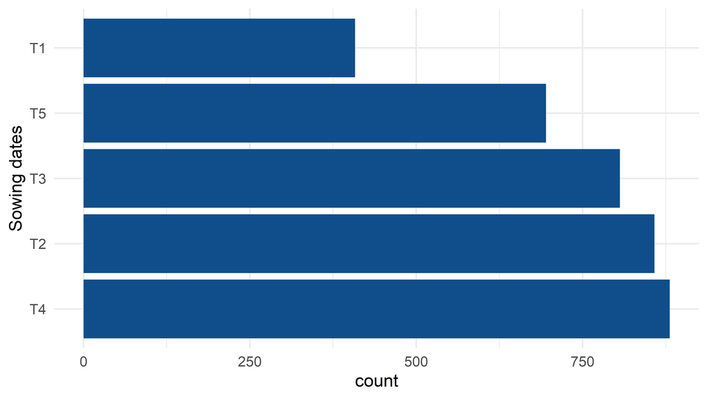

```r
# Bar graphs showing percentage of farmers adopting these practices

library(tidyverse)
library(ggplot2)

bar_chart=function(dat,var){   dat|>     drop_na({{var}})|>     mutate({{var}}:=factor({{var}})|>fct_infreq())|>     ggplot()+     geom_bar(aes(y={{var}}),fill="dodgerblue4")+     theme_minimal(base_size = 16) }

sow_plot=bar_chart(CSISA_KVKestim,SowingSchedule)+labs(y="Sowing dates")

sow_plot
```

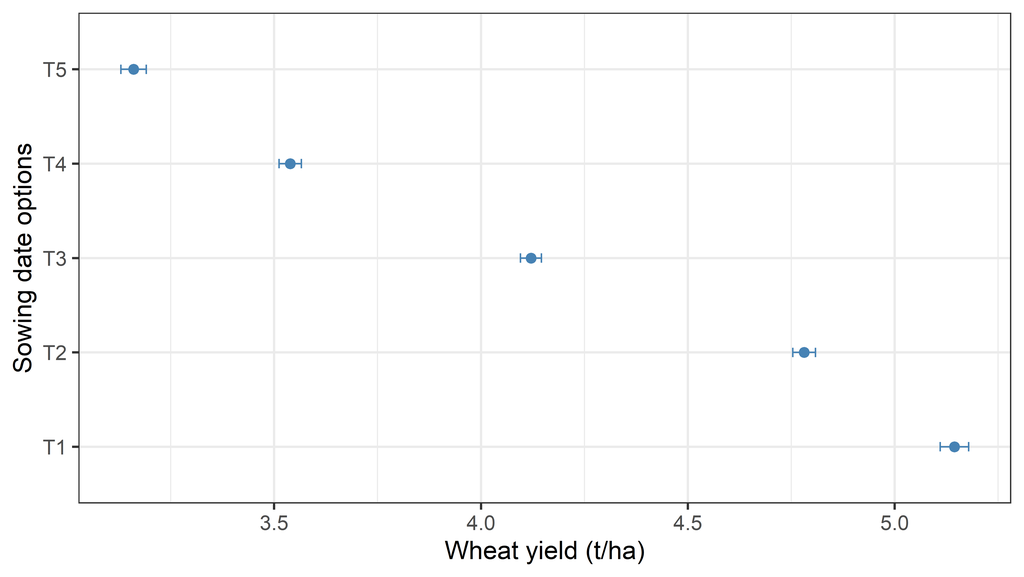

```r
library(ggpubr)
library(tidyverse)

#Sowing dates

SowingDate_Options_Errorplot=   CSISA_KVKestim%>%
  drop_na(SowingSchedule) %>%
  ggerrorplot(x = "SowingSchedule", y = "GrainYield",add = "mean", error.plot = "errorbar", color="steelblue", ggtheme=theme_bw())+
  labs(x="Sowing date options",y="Wheat yield (t/ha)")+
  theme_bw(base_size = 16)+
  coord_flip()
SowingDate_Options_Errorplot
```

## 1.2 Descriptives

```r
library(fBasics)

summ_stats <- fBasics::basicStats(CSISA_KVKestim[,c("GrainYield","VarietyClass_LDV","SoilType_Heavy","SoilType_Medium","SoilType_Low","CropEstablishment_CT","CropEstablishment_CT-line","CropEstablishment_ZT")])

summ_stats <- as.data.frame(t(summ_stats))

# Rename some of the columns for convenience

summ_stats <- summ_stats[c("Mean", "Stdev", "Minimum", "1. Quartile", "Median",  "3. Quartile", "Maximum")] %>%
rename("Lower quartile" = '1. Quartile', "Upper quartile"= "3. Quartile")

summ_stats
```

```
                              Mean    Stdev Minimum Lower quartile Median
GrainYield                4.067177 1.035497    1.39           3.23   4.06
VarietyClass_LDV          0.710526 0.453580    0.00           0.00   1.00
SoilType_Heavy            0.214090 0.410246    0.00           0.00   0.00
SoilType_Medium           0.763980 0.424693    0.00           1.00   1.00
SoilType_Low              0.021930 0.146475    0.00           0.00   0.00
CropEstablishment_CT      0.020285 0.140993    0.00           0.00   0.00
CropEstablishment_CT.line 0.004386 0.066090    0.00           0.00   0.00
CropEstablishment_ZT      0.975329 0.155142    0.00           1.00   1.00
                          Upper quartile Maximum
GrainYield                          4.84    6.74
VarietyClass_LDV                    1.00    1.00
SoilType_Heavy                      0.00    1.00
SoilType_Medium                     1.00    1.00
SoilType_Low                        0.00    1.00
CropEstablishment_CT                0.00    1.00
CropEstablishment_CT.line           0.00    1.00
CropEstablishment_ZT                1.00    1.00
```

# 2 Just-pope production function

Just and Pope (1979) proposed the a three step estimation framework of the effect of inputs on mean yield and risk. The first step involves estimating a production function of any functional form (e.g., quadratic, cobb-douglas) using OLS. We then collect the residuals, square them and put them in a logarithm. We use this log (res^2) as dependent variable in the second stage estimation. This is the variance model. In the final step, we use the inverse of the exponential of the fitted values from the second stage as weights in a weighted least squares (WLS). This three step procedure is also called feasible generalized least sqaures (FGLS) estimation.

```r
ols = lm(GrainYield ~ SowingSchedule+VarietyClass_LDV + SeedRate + CropEstablishment + IrrigationNumber + SoilType + LandType + as.factor(Year)+ District, data = CSISA_KVKestim)
summary(ols)
```

```
Call:
lm(formula = GrainYield ~ SowingSchedule + VarietyClass_LDV +
    SeedRate + CropEstablishment + IrrigationNumber + SoilType +
    LandType + as.factor(Year) + District, data = CSISA_KVKestim)

Residuals:
     Min       1Q   Median       3Q      Max
-2.56769 -0.38434 -0.00054  0.40224  2.43981

Coefficients:
                          Estimate Std. Error t value Pr(>|t|)
(Intercept)               2.772121   0.166600  16.639  < 2e-16 ***
SowingScheduleT2         -0.300546   0.038204  -7.867 4.76e-15 ***
SowingScheduleT3         -0.640101   0.039523 -16.196  < 2e-16 ***
SowingScheduleT4         -1.038753   0.041335 -25.130  < 2e-16 ***
SowingScheduleT5         -1.353139   0.043525 -31.089  < 2e-16 ***
VarietyClass_LDV          0.441173   0.025483  17.313  < 2e-16 ***
SeedRate                 -0.005214   0.002994  -1.741 0.081713 .
CropEstablishmentCT-line  0.641219   0.173942   3.686 0.000231 ***
CropEstablishmentZT       0.662518   0.077162   8.586  < 2e-16 ***
IrrigationNumber          0.492991   0.018425  26.756  < 2e-16 ***
SoilTypeLow               0.178515   0.081896   2.180 0.029339 *
SoilTypeMedium            0.215316   0.037505   5.741 1.02e-08 ***
LandTypeMedium Land       0.047731   0.027150   1.758 0.078826 .
LandTypeUpland           -0.103589   0.055448  -1.868 0.061809 .
as.factor(Year)2017-18   -0.235494   0.039795  -5.918 3.57e-09 ***
as.factor(Year)2018-19   -0.191806   0.037252  -5.149 2.76e-07 ***
as.factor(Year)2019-20   -0.130341   0.039874  -3.269 0.001090 **
as.factor(Year)2020-21   -0.221145   0.040089  -5.516 3.70e-08 ***
DistrictBegusarai        -0.013958   0.055308  -0.252 0.800768
DistrictBuxar             0.069152   0.045503   1.520 0.128670
DistrictDeoria           -0.475402   0.047403 -10.029  < 2e-16 ***
DistrictEast Champaran    0.081392   0.043326   1.879 0.060380 .
DistrictKushinagar       -0.139145   0.050193  -2.772 0.005596 **
DistrictLakhisarai       -0.096428   0.053214  -1.812 0.070053 .
DistrictMadhepura        -0.634577   0.046349 -13.691  < 2e-16 ***
DistrictMuzaffarpur      -0.021590   0.050784  -0.425 0.670758
DistrictRohtas            0.610514   0.060737  10.052  < 2e-16 ***
---
Signif. codes:  0 '***' 0.001 '**' 0.01 '*' 0.05 '.' 0.1 ' ' 1

Residual standard error: 0.6054 on 3621 degrees of freedom
Multiple R-squared:  0.6606,    Adjusted R-squared:  0.6582
F-statistic: 271.1 on 26 and 3621 DF,  p-value: < 2.2e-16
```

```r
# Breusch pagan test for heteroskedasticity
library(lmtest)
bptest(ols)
```

```
    studentized Breusch-Pagan test

data:  ols
BP = 303.78, df = 26, p-value < 2.2e-16
```

```r
CSISA_KVKestim$ols_u=ols$residuals

CSISA_KVKestim$log_ols_u_sqrd=log((CSISA_KVKestim$ols_u)^2)

ols_log_variance = lm(log_ols_u_sqrd ~ SowingSchedule + VarietyClass_LDV + SeedRate + CropEstablishment + IrrigationNumber + SoilType + LandType + as.factor(Year) + District, data = CSISA_KVKestim)
summary(ols_log_variance)
```

```
Call:
lm(formula = log_ols_u_sqrd ~ SowingSchedule + VarietyClass_LDV +
    SeedRate + CropEstablishment + IrrigationNumber + SoilType +
    LandType + as.factor(Year) + District, data = CSISA_KVKestim)

Residuals:
     Min       1Q   Median       3Q      Max
-14.1378  -1.0386   0.5213   1.4610   4.0038

Coefficients:
                         Estimate Std. Error t value Pr(>|t|)
(Intercept)              -2.28710    0.61550  -3.716 0.000206 ***
SowingScheduleT2          0.04563    0.14114   0.323 0.746492
SowingScheduleT3         -0.02897    0.14602  -0.198 0.842725
SowingScheduleT4          0.21919    0.15271   1.435 0.151286
SowingScheduleT5          0.20446    0.16080   1.271 0.203642
VarietyClass_LDV          0.06623    0.09415   0.703 0.481790
SeedRate                  0.02936    0.01106   2.654 0.007993 **
CropEstablishmentCT-line -0.23767    0.64263  -0.370 0.711520
CropEstablishmentZT      -0.93376    0.28507  -3.275 0.001065 **
IrrigationNumber         -0.03279    0.06807  -0.482 0.630079
SoilTypeLow              -0.83666    0.30256  -2.765 0.005717 **
SoilTypeMedium           -0.30802    0.13856  -2.223 0.026279 *
LandTypeMedium Land      -0.09958    0.10031  -0.993 0.320889
LandTypeUpland           -0.07563    0.20485  -0.369 0.712020
as.factor(Year)2017-18   -0.46565    0.14702  -3.167 0.001552 **
as.factor(Year)2018-19   -0.17665    0.13763  -1.284 0.199394
as.factor(Year)2019-20   -0.37713    0.14731  -2.560 0.010506 *
as.factor(Year)2020-21   -0.37383    0.14811  -2.524 0.011643 *
DistrictBegusarai        -0.31749    0.20434  -1.554 0.120331
DistrictBuxar             0.72204    0.16811   4.295 1.79e-05 ***
DistrictDeoria            0.13303    0.17513   0.760 0.447554
DistrictEast Champaran   -0.23871    0.16007  -1.491 0.135972
DistrictKushinagar        0.15601    0.18544   0.841 0.400237
DistrictLakhisarai       -0.09794    0.19660  -0.498 0.618397
DistrictMadhepura        -0.08121    0.17124  -0.474 0.635336
DistrictMuzaffarpur       0.67695    0.18762   3.608 0.000313 ***
DistrictRohtas           -0.23035    0.22439  -1.027 0.304703
---
Signif. codes:  0 '***' 0.001 '**' 0.01 '*' 0.05 '.' 0.1 ' ' 1

Residual standard error: 2.237 on 3621 degrees of freedom
Multiple R-squared:  0.03741,   Adjusted R-squared:  0.0305
F-statistic: 5.412 on 26 and 3621 DF,  p-value: < 2.2e-16
```

```r
# fitted values
CSISA_KVKestim$g_hat=fitted(ols_log_variance)
# Exponential of fitted values
CSISA_KVKestim$h_hat=exp(CSISA_KVKestim$g_hat)
# create weights
CSISA_KVKestim$w=1/CSISA_KVKestim$h_hat

# FGLS
fgls = lm(GrainYield ~ SowingSchedule +VarietyClass_LDV + SeedRate + CropEstablishment + IrrigationNumber + SoilType + LandType +as.factor(Year)+ District, data = CSISA_KVKestim, weight = w)
summary(fgls)
```

```
Call:
lm(formula = GrainYield ~ SowingSchedule + VarietyClass_LDV +
    SeedRate + CropEstablishment + IrrigationNumber + SoilType +
    LandType + as.factor(Year) + District, data = CSISA_KVKestim,
    weights = w)

Weighted Residuals:
    Min      1Q  Median      3Q     Max
-6.5729 -1.2736 -0.0168  1.2824  7.5161

Coefficients:
                          Estimate Std. Error t value Pr(>|t|)
(Intercept)               2.669334   0.181139  14.736  < 2e-16 ***
SowingScheduleT2         -0.294066   0.033419  -8.799  < 2e-16 ***
SowingScheduleT3         -0.627452   0.034741 -18.061  < 2e-16 ***
SowingScheduleT4         -1.056936   0.038154 -27.702  < 2e-16 ***
SowingScheduleT5         -1.376626   0.040011 -34.406  < 2e-16 ***
VarietyClass_LDV          0.435970   0.023947  18.206  < 2e-16 ***
SeedRate                 -0.006412   0.002751  -2.331  0.01981 *
CropEstablishmentCT-line  0.924593   0.228001   4.055 5.11e-05 ***
CropEstablishmentZT       0.867418   0.118098   7.345 2.53e-13 ***
IrrigationNumber          0.455721   0.016756  27.197  < 2e-16 ***
SoilTypeLow               0.088969   0.067682   1.315  0.18876
SoilTypeMedium            0.165849   0.037886   4.378 1.23e-05 ***
LandTypeMedium Land       0.034230   0.025991   1.317  0.18793
LandTypeUpland           -0.131406   0.049275  -2.667  0.00769 **
as.factor(Year)2017-18   -0.116993   0.039639  -2.951  0.00318 **
as.factor(Year)2018-19   -0.116407   0.039095  -2.978  0.00292 **
as.factor(Year)2019-20    0.026882   0.040062   0.671  0.50226
as.factor(Year)2020-21   -0.081225   0.040821  -1.990  0.04669 *
DistrictBegusarai        -0.005822   0.047022  -0.124  0.90148
DistrictBuxar             0.026466   0.049100   0.539  0.58991
DistrictDeoria           -0.439702   0.043987  -9.996  < 2e-16 ***
DistrictEast Champaran    0.119128   0.038390   3.103  0.00193 **
DistrictKushinagar       -0.079281   0.046975  -1.688  0.09155 .
DistrictLakhisarai       -0.146629   0.048949  -2.996  0.00276 **
DistrictMadhepura        -0.630738   0.041187 -15.314  < 2e-16 ***
DistrictMuzaffarpur      -0.012255   0.054433  -0.225  0.82188
DistrictRohtas            0.611227   0.059065  10.348  < 2e-16 ***
---
Signif. codes:  0 '***' 0.001 '**' 0.01 '*' 0.05 '.' 0.1 ' ' 1

Residual standard error: 1.89 on 3621 degrees of freedom
Multiple R-squared:  0.6972,    Adjusted R-squared:  0.695
F-statistic: 320.6 on 26 and 3621 DF,  p-value: < 2.2e-16
```

```r
library(stargazer)
stargazer(ols, fgls,ols_log_variance,
          column.labels=c("OLS","FGLS","ols_log_variance"),
          type="text",out ="JP_results.html",
          keep.stat=c("n","rsq"))
```

```
===========================================================
                                Dependent variable:
                         ----------------------------------
                             GrainYield      log_ols_u_sqrd
                            OLS      FGLS         ols
                            (1)       (2)         (3)
-----------------------------------------------------------
SowingScheduleT2         -0.301*** -0.294***     0.046
                          (0.038)   (0.033)     (0.141)

SowingScheduleT3         -0.640*** -0.627***     -0.029
                          (0.040)   (0.035)     (0.146)

SowingScheduleT4         -1.039*** -1.057***     0.219
                          (0.041)   (0.038)     (0.153)

SowingScheduleT5         -1.353*** -1.377***     0.204
                          (0.044)   (0.040)     (0.161)

VarietyClass_LDV         0.441***  0.436***      0.066
                          (0.025)   (0.024)     (0.094)

SeedRate                  -0.005*  -0.006**     0.029***
                          (0.003)   (0.003)     (0.011)

CropEstablishmentCT-line 0.641***  0.925***      -0.238
                          (0.174)   (0.228)     (0.643)

CropEstablishmentZT      0.663***  0.867***    -0.934***
                          (0.077)   (0.118)     (0.285)

IrrigationNumber         0.493***  0.456***      -0.033
                          (0.018)   (0.017)     (0.068)

SoilTypeLow               0.179**    0.089     -0.837***
                          (0.082)   (0.068)     (0.303)

SoilTypeMedium           0.215***  0.166***     -0.308**
                          (0.038)   (0.038)     (0.139)

```

[output cut: 38 more lines]

```

DistrictMuzaffarpur       -0.022    -0.012      0.677***
                          (0.051)   (0.054)     (0.188)

DistrictRohtas           0.611***  0.611***      -0.230
                          (0.061)   (0.059)     (0.224)

Constant                 2.772***  2.669***    -2.287***
                          (0.167)   (0.181)     (0.616)

-----------------------------------------------------------
Observations               3,648     3,648       3,648
R2                         0.661     0.697       0.037
===========================================================
Note:                           *p<0.1; **p<0.05; ***p<0.01
```

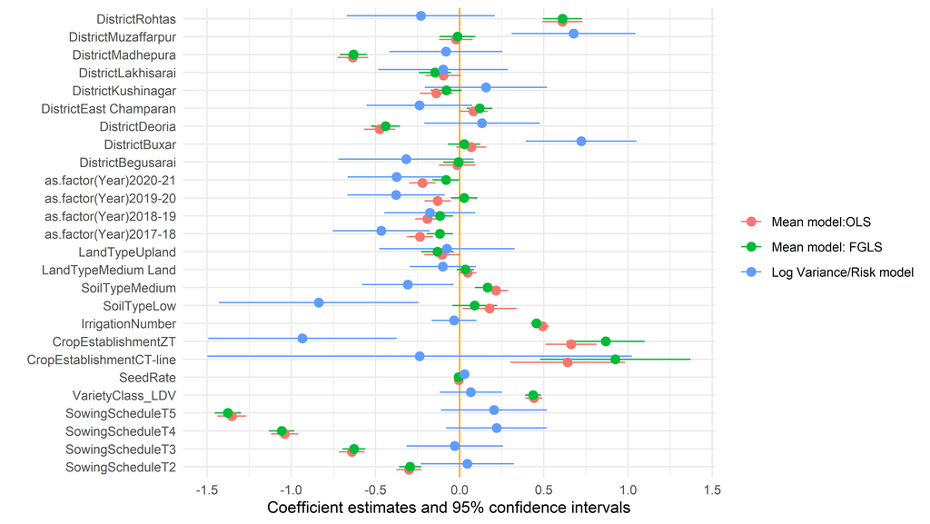

```r
library(modelsummary)
list_models = list("Mean model:OLS"=ols,"Mean model: FGLS"=fgls, "Log Variance/Risk model"=ols_log_variance)

b <- list(geom_vline(xintercept = 0, color = 'orange'))
modelplot(list_models,background = b,coef_omit = "Interc")
```

```r
modelsummary(list_models, stars=TRUE,output="tables/JP_results.docx")
```

## 2.1 Contribution of sowing dates and varieties to yield and risk

```r
anova(ols)
```

```
Analysis of Variance Table

Response: GrainYield
                    Df  Sum Sq Mean Sq   F value    Pr(>F)
SowingSchedule       4 1731.38  432.84 1180.8898 < 2.2e-16 ***
VarietyClass_LDV     1  160.32  160.32  437.3857 < 2.2e-16 ***
SeedRate             1   32.08   32.08   87.5170 < 2.2e-16 ***
CropEstablishment    2   12.40    6.20   16.9098 4.901e-08 ***
IrrigationNumber     1  360.23  360.23  982.7804 < 2.2e-16 ***
SoilType             2   11.95    5.97   16.2945 9.017e-08 ***
LandType             2   16.33    8.16   22.2729 2.432e-10 ***
as.factor(Year)      4    7.77    1.94    5.3013 0.0002958 ***
District             9  250.82   27.87   76.0322 < 2.2e-16 ***
Residuals         3621 1327.24    0.37
---
Signif. codes:  0 '***' 0.001 '**' 0.01 '*' 0.05 '.' 0.1 ' ' 1
```

```r
anova(fgls)
```

```
Analysis of Variance Table

Response: GrainYield
                    Df  Sum Sq Mean Sq  F value    Pr(>F)
SowingSchedule       4 20279.6  5069.9 1419.573 < 2.2e-16 ***
VarietyClass_LDV     1  1645.2  1645.2  460.648 < 2.2e-16 ***
SeedRate             1   372.7   372.7  104.364 < 2.2e-16 ***
CropEstablishment    2    93.5    46.8   13.094 2.158e-06 ***
IrrigationNumber     1  3673.3  3673.3 1028.525 < 2.2e-16 ***
SoilType             2   288.1   144.1   40.339 < 2.2e-16 ***
LandType             2   240.6   120.3   33.690 3.186e-15 ***
as.factor(Year)      4    82.5    20.6    5.778  0.000124 ***
District             9  3096.3   344.0   96.330 < 2.2e-16 ***
Residuals         3621 12932.1     3.6
---
Signif. codes:  0 '***' 0.001 '**' 0.01 '*' 0.05 '.' 0.1 ' ' 1
```

```r
anova(ols_log_variance)
```

```
Analysis of Variance Table

Response: log_ols_u_sqrd
                    Df  Sum Sq Mean Sq F value    Pr(>F)
SowingSchedule       4    50.7  12.684  2.5354 0.0382922 *
VarietyClass_LDV     1     5.6   5.565  1.1123 0.2916550
SeedRate             1     1.8   1.811  0.3620 0.5474131
CropEstablishment    2   110.3  55.169 11.0272 1.681e-05 ***
IrrigationNumber     1     4.3   4.306  0.8607 0.3536113
SoilType             2    38.1  19.049  3.8075 0.0222923 *
LandType             2     3.9   1.942  0.3881 0.6783869
as.factor(Year)      4   113.7  28.420  5.6806 0.0001482 ***
District             9   375.6  41.735  8.3420 2.093e-12 ***
Residuals         3621 18115.8   5.003
---
Signif. codes:  0 '***' 0.001 '**' 0.01 '*' 0.05 '.' 0.1 ' ' 1
```

### 2.1.1 Shapley value regression

```r
## Shapley value regression -----
library(ShapleyValue)

y <- CSISA_KVKestim$GrainYield
x=subset(CSISA_KVKestim, select=c("SowingSchedule","VarietyClass_LDV","SeedRate","CropEstablishment","IrrigationNumber","SoilType","LandType","Year","District"))

value <- shapleyvalue(y,x)

library(kableExtra)
value %>%
  kbl() %>%
  kable_classic(full_width = F, html_font = "Cambria")
```

|  | SowingSchedule | VarietyClass_LDV | SeedRate | CropEstablishment | IrrigationNumber | SoilType | LandType | Year | District |
| --- | --- | --- | --- | --- | --- | --- | --- | --- | --- |
| Shapley Value | 0.2533 | 0.0944 | 0.0219 | 0.0054 | 0.1877 | 0.0042 | 0.0074 | 0.0063 | 0.0800 |
| Standardized Shapley Value | 0.3834 | 0.1429 | 0.0332 | 0.0082 | 0.2842 | 0.0064 | 0.0111 | 0.0095 | 0.1211 |

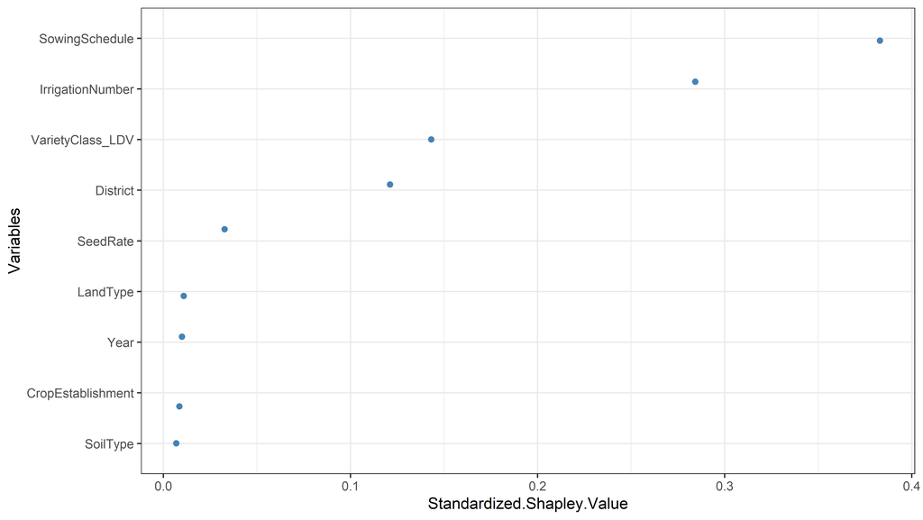

```r
shapleyvaluet=as.data.frame(t(value))
shapleyvaluet=cbind(rownames(shapleyvaluet), data.frame(shapleyvaluet, row.names=NULL))
names(shapleyvaluet)[1]="vars"

library(ggplot2)
shapleyvalueplot=ggplot(shapleyvaluet,aes(x=reorder(vars,Standardized.Shapley.Value),y=Standardized.Shapley.Value))+
  geom_jitter(color="steelblue")+
  coord_flip()+
  labs(x="Variables",y="Standardized.Shapley.Value")
previous_theme <- theme_set(theme_bw())
shapleyvalueplot
```

```r
ggsave("figures/Mean_shapleyvalueplot.png",dpi=300)


# Variance model
y <- CSISA_KVKestim$log_ols_u_sqrd
x=subset(CSISA_KVKestim, select=c("SowingSchedule","VarietyClass_LDV","SeedRate","CropEstablishment","IrrigationNumber","SoilType","LandType","Year","District"))

value <- shapleyvalue(y,x)

library(kableExtra)
value %>%
  kbl() %>%
  kable_classic(full_width = F, html_font = "Cambria")
```

|  | SowingSchedule | VarietyClass_LDV | SeedRate | CropEstablishment | IrrigationNumber | SoilType | LandType | Year | District |
| --- | --- | --- | --- | --- | --- | --- | --- | --- | --- |
| Shapley Value | 0.0024 | 0.0001 | 0.0014 | 0.0044 | 0.0002 | 0.0029 | 0.0008 | 0.0060 | 0.0194 |
| Standardized Shapley Value | 0.0629 | 0.0028 | 0.0365 | 0.1168 | 0.0057 | 0.0765 | 0.0204 | 0.1611 | 0.5173 |

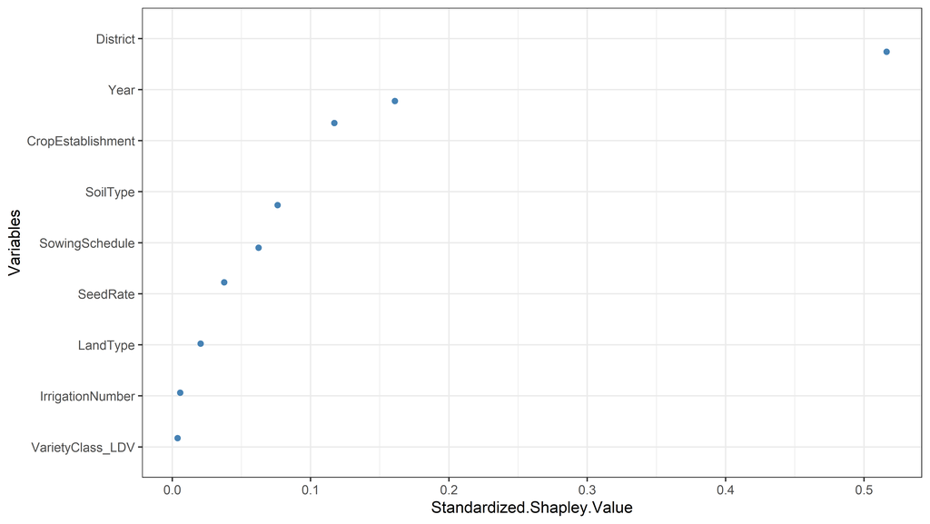

```r
shapleyvaluet=as.data.frame(t(value))
shapleyvaluet=cbind(rownames(shapleyvaluet), data.frame(shapleyvaluet, row.names=NULL))
names(shapleyvaluet)[1]="vars"

library(ggplot2)
shapleyvalueplot=ggplot(shapleyvaluet,aes(x=reorder(vars,Standardized.Shapley.Value),y=Standardized.Shapley.Value))+
  geom_jitter(color="steelblue")+
  coord_flip()+
  labs(x="Variables",y="Standardized.Shapley.Value")
previous_theme <- theme_set(theme_bw())
shapleyvalueplot
```

```r
ggsave("figures/Variance_shapleyvalueplot.png",dpi=300)
```

# 3 Moment approach

Antle (1983) extended the Just-Pope algorithm by including skewness as a measure of downside risk. The reason for the extension was the the Just-Pope approach considers variance as a measure of risk but variance doesnot distinguish unexpected bad events and good events. Skewness allows characterization of the unexpected downside effects.

```r
ols_mean=lm(GrainYield ~ SowingSchedule+VarietyClass_LDV + SeedRate + CropEstablishment + IrrigationNumber + SoilType + LandType + as.factor(Year)+ District, data = CSISA_KVKestim)
summary(ols_mean)
```

```
Call:
lm(formula = GrainYield ~ SowingSchedule + VarietyClass_LDV +
    SeedRate + CropEstablishment + IrrigationNumber + SoilType +
    LandType + as.factor(Year) + District, data = CSISA_KVKestim)

Residuals:
     Min       1Q   Median       3Q      Max
-2.56769 -0.38434 -0.00054  0.40224  2.43981

Coefficients:
                          Estimate Std. Error t value Pr(>|t|)
(Intercept)               2.772121   0.166600  16.639  < 2e-16 ***
SowingScheduleT2         -0.300546   0.038204  -7.867 4.76e-15 ***
SowingScheduleT3         -0.640101   0.039523 -16.196  < 2e-16 ***
SowingScheduleT4         -1.038753   0.041335 -25.130  < 2e-16 ***
SowingScheduleT5         -1.353139   0.043525 -31.089  < 2e-16 ***
VarietyClass_LDV          0.441173   0.025483  17.313  < 2e-16 ***
SeedRate                 -0.005214   0.002994  -1.741 0.081713 .
CropEstablishmentCT-line  0.641219   0.173942   3.686 0.000231 ***
CropEstablishmentZT       0.662518   0.077162   8.586  < 2e-16 ***
IrrigationNumber          0.492991   0.018425  26.756  < 2e-16 ***
SoilTypeLow               0.178515   0.081896   2.180 0.029339 *
SoilTypeMedium            0.215316   0.037505   5.741 1.02e-08 ***
LandTypeMedium Land       0.047731   0.027150   1.758 0.078826 .
LandTypeUpland           -0.103589   0.055448  -1.868 0.061809 .
as.factor(Year)2017-18   -0.235494   0.039795  -5.918 3.57e-09 ***
as.factor(Year)2018-19   -0.191806   0.037252  -5.149 2.76e-07 ***
as.factor(Year)2019-20   -0.130341   0.039874  -3.269 0.001090 **
as.factor(Year)2020-21   -0.221145   0.040089  -5.516 3.70e-08 ***
DistrictBegusarai        -0.013958   0.055308  -0.252 0.800768
DistrictBuxar             0.069152   0.045503   1.520 0.128670
DistrictDeoria           -0.475402   0.047403 -10.029  < 2e-16 ***
DistrictEast Champaran    0.081392   0.043326   1.879 0.060380 .
DistrictKushinagar       -0.139145   0.050193  -2.772 0.005596 **
DistrictLakhisarai       -0.096428   0.053214  -1.812 0.070053 .
DistrictMadhepura        -0.634577   0.046349 -13.691  < 2e-16 ***
DistrictMuzaffarpur      -0.021590   0.050784  -0.425 0.670758
DistrictRohtas            0.610514   0.060737  10.052  < 2e-16 ***
---
Signif. codes:  0 '***' 0.001 '**' 0.01 '*' 0.05 '.' 0.1 ' ' 1

Residual standard error: 0.6054 on 3621 degrees of freedom
Multiple R-squared:  0.6606,    Adjusted R-squared:  0.6582
F-statistic: 271.1 on 26 and 3621 DF,  p-value: < 2.2e-16
```

```r
ols_variance=lm(ols_u^2~SowingSchedule+VarietyClass_LDV + SeedRate + CropEstablishment + IrrigationNumber + SoilType + LandType + as.factor(Year)+ District, data = CSISA_KVKestim)
summary(ols_variance)
```

```
Call:
lm(formula = ols_u^2 ~ SowingSchedule + VarietyClass_LDV + SeedRate +
    CropEstablishment + IrrigationNumber + SoilType + LandType +
    as.factor(Year) + District, data = CSISA_KVKestim)

Residuals:
    Min      1Q  Median      3Q     Max
-0.7666 -0.2941 -0.1437  0.0914  5.8781

Coefficients:
                          Estimate Std. Error t value Pr(>|t|)
(Intercept)               0.026239   0.147010   0.178 0.858351
SowingScheduleT2          0.059411   0.033711   1.762 0.078094 .
SowingScheduleT3          0.012820   0.034876   0.368 0.713202
SowingScheduleT4          0.128153   0.036475   3.513 0.000448 ***
SowingScheduleT5          0.189214   0.038407   4.927 8.75e-07 ***
VarietyClass_LDV         -0.047251   0.022486  -2.101 0.035681 *
SeedRate                  0.007725   0.002642   2.924 0.003480 **
CropEstablishmentCT-line  0.002554   0.153490   0.017 0.986725
CropEstablishmentZT      -0.125401   0.068089  -1.842 0.065599 .
IrrigationNumber          0.047345   0.016259   2.912 0.003614 **
SoilTypeLow              -0.185661   0.072266  -2.569 0.010236 *
SoilTypeMedium           -0.021887   0.033095  -0.661 0.508448
LandTypeMedium Land      -0.059028   0.023958  -2.464 0.013794 *
LandTypeUpland           -0.066748   0.048928  -1.364 0.172582
as.factor(Year)2017-18   -0.152943   0.035116  -4.355 1.37e-05 ***
as.factor(Year)2018-19   -0.021560   0.032872  -0.656 0.511933
as.factor(Year)2019-20   -0.050702   0.035186  -1.441 0.149674
as.factor(Year)2020-21   -0.109369   0.035375  -3.092 0.002005 **
DistrictBegusarai        -0.045846   0.048805  -0.939 0.347606
DistrictBuxar             0.346208   0.040153   8.622  < 2e-16 ***
DistrictDeoria            0.018077   0.041829   0.432 0.665652
DistrictEast Champaran   -0.069652   0.038232  -1.822 0.068562 .
DistrictKushinagar        0.020793   0.044291   0.469 0.638771
DistrictLakhisarai        0.021967   0.046956   0.468 0.639944
DistrictMadhepura         0.047363   0.040899   1.158 0.246924
DistrictMuzaffarpur       0.215427   0.044813   4.807 1.59e-06 ***
DistrictRohtas            0.016187   0.053595   0.302 0.762647
---
Signif. codes:  0 '***' 0.001 '**' 0.01 '*' 0.05 '.' 0.1 ' ' 1

Residual standard error: 0.5342 on 3621 degrees of freedom
Multiple R-squared:  0.08327,   Adjusted R-squared:  0.07669
F-statistic: 12.65 on 26 and 3621 DF,  p-value: < 2.2e-16
```

```r
ols_skewness=lm(ols_u^3~SowingSchedule+VarietyClass_LDV + SeedRate + CropEstablishment + IrrigationNumber + SoilType + LandType + as.factor(Year)+ District, data = CSISA_KVKestim)
summary(ols_skewness)
```

```
Call:
lm(formula = ols_u^3 ~ SowingSchedule + VarietyClass_LDV + SeedRate +
    CropEstablishment + IrrigationNumber + SoilType + LandType +
    as.factor(Year) + District, data = CSISA_KVKestim)

Residuals:
     Min       1Q   Median       3Q      Max
-16.5786  -0.1467   0.0122   0.1718  14.4038

Coefficients:
                           Estimate Std. Error t value Pr(>|t|)
(Intercept)               1.331e-01  2.655e-01   0.501   0.6162
SowingScheduleT2         -2.934e-02  6.088e-02  -0.482   0.6299
SowingScheduleT3         -3.109e-02  6.299e-02  -0.494   0.6216
SowingScheduleT4          1.034e-01  6.587e-02   1.570   0.1165
SowingScheduleT5          1.231e-01  6.936e-02   1.774   0.0761 .
VarietyClass_LDV         -2.227e-02  4.061e-02  -0.548   0.5834
SeedRate                  1.539e-05  4.771e-03   0.003   0.9974
CropEstablishmentCT-line -5.131e-01  2.772e-01  -1.851   0.0643 .
CropEstablishmentZT      -3.956e-01  1.230e-01  -3.217   0.0013 **
IrrigationNumber          3.120e-02  2.936e-02   1.062   0.2881
SoilTypeLow               1.854e-01  1.305e-01   1.421   0.1555
SoilTypeMedium            1.303e-01  5.977e-02   2.179   0.0294 *
LandTypeMedium Land       6.540e-02  4.327e-02   1.512   0.1307
LandTypeUpland            1.084e-01  8.836e-02   1.227   0.2200
as.factor(Year)2017-18    2.080e-02  6.342e-02   0.328   0.7429
as.factor(Year)2018-19    9.287e-02  5.937e-02   1.564   0.1178
as.factor(Year)2019-20   -1.369e-01  6.355e-02  -2.154   0.0313 *
as.factor(Year)2020-21    8.989e-02  6.389e-02   1.407   0.1595
DistrictBegusarai         1.338e-02  8.814e-02   0.152   0.8793
DistrictBuxar            -1.238e-01  7.252e-02  -1.708   0.0878 .
DistrictDeoria           -8.820e-02  7.554e-02  -1.168   0.2431
DistrictEast Champaran    2.585e-03  6.905e-02   0.037   0.9701
DistrictKushinagar       -9.218e-02  7.999e-02  -1.152   0.2492
DistrictLakhisarai        4.759e-02  8.480e-02   0.561   0.5747
DistrictMadhepura        -3.641e-03  7.386e-02  -0.049   0.9607
DistrictMuzaffarpur      -1.022e-01  8.093e-02  -1.262   0.2069
DistrictRohtas            1.814e-03  9.679e-02   0.019   0.9851
---
Signif. codes:  0 '***' 0.001 '**' 0.01 '*' 0.05 '.' 0.1 ' ' 1

Residual standard error: 0.9648 on 3621 degrees of freedom
Multiple R-squared:  0.01842,   Adjusted R-squared:  0.01137
F-statistic: 2.613 on 26 and 3621 DF,  p-value: 1.508e-05
```

```r
ols_kurtosis=lm(ols_u^4~SowingSchedule+VarietyClass_LDV + SeedRate + CropEstablishment + IrrigationNumber + SoilType + LandType + as.factor(Year)+ District, data = CSISA_KVKestim)
summary(ols_kurtosis)
```

```
Call:
lm(formula = ols_u^4 ~ SowingSchedule + VarietyClass_LDV + SeedRate +
    CropEstablishment + IrrigationNumber + SoilType + LandType +
    as.factor(Year) + District, data = CSISA_KVKestim)

Residuals:
   Min     1Q Median     3Q    Max
-1.890 -0.519 -0.247  0.044 41.895

Coefficients:
                         Estimate Std. Error t value Pr(>|t|)
(Intercept)              -0.78854    0.43850  -1.798 0.072219 .
SowingScheduleT2          0.21106    0.10055   2.099 0.035886 *
SowingScheduleT3          0.06119    0.10403   0.588 0.556407
SowingScheduleT4          0.28845    0.10880   2.651 0.008053 **
SowingScheduleT5          0.48739    0.11456   4.254 2.15e-05 ***
VarietyClass_LDV         -0.22727    0.06707  -3.388 0.000710 ***
SeedRate                  0.01823    0.00788   2.313 0.020793 *
CropEstablishmentCT-line  0.08120    0.45783   0.177 0.859240
CropEstablishmentZT      -0.05976    0.20309  -0.294 0.768599
IrrigationNumber          0.15189    0.04850   3.132 0.001750 **
SoilTypeLow              -0.29516    0.21555  -1.369 0.170997
SoilTypeMedium            0.05895    0.09871   0.597 0.550410
LandTypeMedium Land      -0.16283    0.07146  -2.279 0.022754 *
LandTypeUpland           -0.20286    0.14594  -1.390 0.164619
as.factor(Year)2017-18   -0.38553    0.10474  -3.681 0.000236 ***
as.factor(Year)2018-19   -0.06095    0.09805  -0.622 0.534252
as.factor(Year)2019-20    0.02559    0.10495   0.244 0.807372
as.factor(Year)2020-21   -0.26246    0.10552  -2.487 0.012913 *
DistrictBegusarai        -0.02043    0.14557  -0.140 0.888421
DistrictBuxar             0.98589    0.11977   8.232 2.55e-16 ***
DistrictDeoria            0.01428    0.12477   0.114 0.908867
DistrictEast Champaran   -0.06788    0.11404  -0.595 0.551718
DistrictKushinagar        0.07752    0.13211   0.587 0.557389
DistrictLakhisarai        0.07637    0.14006   0.545 0.585616
DistrictMadhepura         0.15332    0.12199   1.257 0.208895
DistrictMuzaffarpur       0.49656    0.13367   3.715 0.000206 ***
DistrictRohtas            0.16020    0.15986   1.002 0.316340
---
Signif. codes:  0 '***' 0.001 '**' 0.01 '*' 0.05 '.' 0.1 ' ' 1

Residual standard error: 1.594 on 3621 degrees of freedom
Multiple R-squared:  0.06319,   Adjusted R-squared:  0.05647
F-statistic: 9.395 on 26 and 3621 DF,  p-value: < 2.2e-16
```

```r
library(stargazer)
stargazer(ols_mean, ols_variance,ols_skewness,ols_kurtosis,
          column.labels=c("Mean","Variance","Skewness","Kurtosis"),
          type="text", out ="Moments_results.html",
          keep.stat=c("n","rsq"))
```

```
=================================================================
                                   Dependent variable:
                         ----------------------------------------
                         GrainYield  ols_u2    ols_u3    ols_u4
                            Mean    Variance  Skewness  Kurtosis
                            (1)        (2)       (3)       (4)
-----------------------------------------------------------------
SowingScheduleT2         -0.301***   0.059*    -0.029    0.211**
                          (0.038)    (0.034)   (0.061)   (0.101)

SowingScheduleT3         -0.640***    0.013    -0.031     0.061
                          (0.040)    (0.035)   (0.063)   (0.104)

SowingScheduleT4         -1.039***  0.128***    0.103   0.288***
                          (0.041)    (0.036)   (0.066)   (0.109)

SowingScheduleT5         -1.353***  0.189***   0.123*   0.487***
                          (0.044)    (0.038)   (0.069)   (0.115)

VarietyClass_LDV          0.441***  -0.047**   -0.022   -0.227***
                          (0.025)    (0.022)   (0.041)   (0.067)

SeedRate                  -0.005*   0.008***   0.00002   0.018**
                          (0.003)    (0.003)   (0.005)   (0.008)

CropEstablishmentCT-line  0.641***    0.003    -0.513*    0.081
                          (0.174)    (0.153)   (0.277)   (0.458)

CropEstablishmentZT       0.663***   -0.125*  -0.396***  -0.060
                          (0.077)    (0.068)   (0.123)   (0.203)

IrrigationNumber          0.493***  0.047***    0.031   0.152***
                          (0.018)    (0.016)   (0.029)   (0.048)

SoilTypeLow               0.179**   -0.186**    0.185    -0.295
                          (0.082)    (0.072)   (0.131)   (0.216)

SoilTypeMedium            0.215***   -0.022    0.130**    0.059
                          (0.038)    (0.033)   (0.060)   (0.099)

```

[output cut: 38 more lines]

```

DistrictMuzaffarpur        -0.022   0.215***   -0.102   0.497***
                          (0.051)    (0.045)   (0.081)   (0.134)

DistrictRohtas            0.611***    0.016     0.002     0.160
                          (0.061)    (0.054)   (0.097)   (0.160)

Constant                  2.772***    0.026     0.133    -0.789*
                          (0.167)    (0.147)   (0.266)   (0.438)

-----------------------------------------------------------------
Observations               3,648      3,648     3,648     3,648
R2                         0.661      0.083     0.018     0.063
=================================================================
Note:                                 *p<0.1; **p<0.05; ***p<0.01
```

```r
library(modelsummary)
list_models_moments = list("Mean model"=ols_mean, "Variance model"=ols_variance,"Skewness model"=ols_skewness,"Kurtosis model"=ols_kurtosis)

modelsummary(list_models_moments,stars=TRUE)
```

|  | Mean model | Variance model | Skewness model | Kurtosis model |
| --- | --- | --- | --- | --- |
| (Intercept) | 2.772*** | 0.026 | 0.133 | -0.789+ |
|  | (0.167) | (0.147) | (0.266) | (0.438) |
| SowingScheduleT2 | -0.301*** | 0.059+ | -0.029 | 0.211* |
|  | (0.038) | (0.034) | (0.061) | (0.101) |
| SowingScheduleT3 | -0.640*** | 0.013 | -0.031 | 0.061 |
|  | (0.040) | (0.035) | (0.063) | (0.104) |
| SowingScheduleT4 | -1.039*** | 0.128*** | 0.103 | 0.288** |
|  | (0.041) | (0.036) | (0.066) | (0.109) |
| SowingScheduleT5 | -1.353*** | 0.189*** | 0.123+ | 0.487*** |
|  | (0.044) | (0.038) | (0.069) | (0.115) |
| VarietyClass_LDV | 0.441*** | -0.047* | -0.022 | -0.227*** |
|  | (0.025) | (0.022) | (0.041) | (0.067) |
| SeedRate | -0.005+ | 0.008** | 0.000 | 0.018* |
|  | (0.003) | (0.003) | (0.005) | (0.008) |
| CropEstablishmentCT-line | 0.641*** | 0.003 | -0.513+ | 0.081 |
|  | (0.174) | (0.153) | (0.277) | (0.458) |
| CropEstablishmentZT | 0.663*** | -0.125+ | -0.396** | -0.060 |
|  | (0.077) | (0.068) | (0.123) | (0.203) |
| IrrigationNumber | 0.493*** | 0.047** | 0.031 | 0.152** |
|  | (0.018) | (0.016) | (0.029) | (0.048) |
| SoilTypeLow | 0.179* | -0.186* | 0.185 | -0.295 |
|  | (0.082) | (0.072) | (0.131) | (0.216) |
| SoilTypeMedium | 0.215*** | -0.022 | 0.130* | 0.059 |
|  | (0.038) | (0.033) | (0.060) | (0.099) |
| LandTypeMedium Land | 0.048+ | -0.059* | 0.065 | -0.163* |
|  | (0.027) | (0.024) | (0.043) | (0.071) |
| LandTypeUpland | -0.104+ | -0.067 | 0.108 | -0.203 |
|  | (0.055) | (0.049) | (0.088) | (0.146) |
| as.factor(Year)2017-18 | -0.235*** | -0.153*** | 0.021 | -0.386*** |
|  | (0.040) | (0.035) | (0.063) | (0.105) |
| as.factor(Year)2018-19 | -0.192*** | -0.022 | 0.093 | -0.061 |
|  | (0.037) | (0.033) | (0.059) | (0.098) |
| as.factor(Year)2019-20 | -0.130** | -0.051 | -0.137* | 0.026 |
|  | (0.040) | (0.035) | (0.064) | (0.105) |
| as.factor(Year)2020-21 | -0.221*** | -0.109** | 0.090 | -0.262* |
|  | (0.040) | (0.035) | (0.064) | (0.106) |
| DistrictBegusarai | -0.014 | -0.046 | 0.013 | -0.020 |
|  | (0.055) | (0.049) | (0.088) | (0.146) |
| DistrictBuxar | 0.069 | 0.346*** | -0.124+ | 0.986*** |
|  | (0.046) | (0.040) | (0.073) | (0.120) |
| DistrictDeoria | -0.475*** | 0.018 | -0.088 | 0.014 |
|  | (0.047) | (0.042) | (0.076) | (0.125) |
| DistrictEast Champaran | 0.081+ | -0.070+ | 0.003 | -0.068 |
|  | (0.043) | (0.038) | (0.069) | (0.114) |
| DistrictKushinagar | -0.139** | 0.021 | -0.092 | 0.078 |
|  | (0.050) | (0.044) | (0.080) | (0.132) |
| DistrictLakhisarai | -0.096+ | 0.022 | 0.048 | 0.076 |
|  | (0.053) | (0.047) | (0.085) | (0.140) |
| DistrictMadhepura | -0.635*** | 0.047 | -0.004 | 0.153 |
|  | (0.046) | (0.041) | (0.074) | (0.122) |
| DistrictMuzaffarpur | -0.022 | 0.215*** | -0.102 | 0.497*** |
|  | (0.051) | (0.045) | (0.081) | (0.134) |
| DistrictRohtas | 0.611*** | 0.016 | 0.002 | 0.160 |
|  | (0.061) | (0.054) | (0.097) | (0.160) |
| Num.Obs. | 3648 | 3648 | 3648 | 3648 |
| R2 | 0.661 | 0.083 | 0.018 | 0.063 |
| R2 Adj. | 0.658 | 0.077 | 0.011 | 0.056 |
| AIC | 6720.2 | 5807.5 | 10120.3 | 13781.0 |
| BIC | 6893.8 | 5981.2 | 10294.0 | 13954.6 |
| Log.Lik. | -3332.089 | -2875.757 | -5032.155 | -6862.493 |
| F | 271.065 | 12.651 | 2.613 | 9.395 |
| RMSE | 0.60 | 0.53 | 0.96 | 1.59 |

+ p < 0.1, * p < 0.05, ** p < 0.01, *** p < 0.001

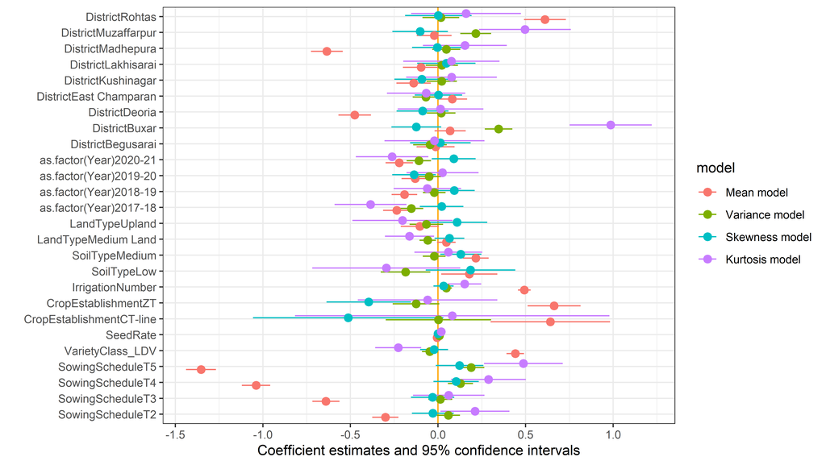

```r
b <- list(geom_vline(xintercept = 0, color = 'orange'))

modelplot(list_models_moments,stars=TRUE, coef_omit = "Interc", background=b)
```

```r
modelsummary(list_models_moments, stars=TRUE,output="tables/Moments_results.docx")
```

## 3.1 Contribution to moments

### 3.1.1 ANOVA

```r
anova(ols_mean)
```

```
Analysis of Variance Table

Response: GrainYield
                    Df  Sum Sq Mean Sq   F value    Pr(>F)
SowingSchedule       4 1731.38  432.84 1180.8898 < 2.2e-16 ***
VarietyClass_LDV     1  160.32  160.32  437.3857 < 2.2e-16 ***
SeedRate             1   32.08   32.08   87.5170 < 2.2e-16 ***
CropEstablishment    2   12.40    6.20   16.9098 4.901e-08 ***
IrrigationNumber     1  360.23  360.23  982.7804 < 2.2e-16 ***
SoilType             2   11.95    5.97   16.2945 9.017e-08 ***
LandType             2   16.33    8.16   22.2729 2.432e-10 ***
as.factor(Year)      4    7.77    1.94    5.3013 0.0002958 ***
District             9  250.82   27.87   76.0322 < 2.2e-16 ***
Residuals         3621 1327.24    0.37
---
Signif. codes:  0 '***' 0.001 '**' 0.01 '*' 0.05 '.' 0.1 ' ' 1
```

```r
anova(ols_variance)
```

```
Analysis of Variance Table

Response: ols_u^2
                    Df  Sum Sq Mean Sq F value    Pr(>F)
SowingSchedule       4   17.04  4.2591 14.9227 4.230e-12 ***
VarietyClass_LDV     1    0.10  0.0988  0.3461  0.556380
SeedRate             1    0.00  0.0043  0.0152  0.901902
CropEstablishment    2    2.89  1.4428  5.0551  0.006422 **
IrrigationNumber     1    7.60  7.5970 26.6178 2.613e-07 ***
SoilType             2    1.47  0.7354  2.5767  0.076165 .
LandType             2    1.72  0.8581  3.0064  0.049592 *
as.factor(Year)      4   10.52  2.6297  9.2137 2.098e-07 ***
District             9   52.55  5.8389 20.4578 < 2.2e-16 ***
Residuals         3621 1033.47  0.2854
---
Signif. codes:  0 '***' 0.001 '**' 0.01 '*' 0.05 '.' 0.1 ' ' 1
```

```r
anova(ols_skewness)
```

```
Analysis of Variance Table

Response: ols_u^3
                    Df Sum Sq Mean Sq F value    Pr(>F)
SowingSchedule       4   11.1  2.7831  2.9897   0.01779 *
VarietyClass_LDV     1    0.0  0.0047  0.0050   0.94340
SeedRate             1    0.8  0.8466  0.9095   0.34032
CropEstablishment    2    6.1  3.0521  3.2786   0.03779 *
IrrigationNumber     1    0.3  0.2568  0.2759   0.59943
SoilType             2    7.4  3.6933  3.9674   0.01900 *
LandType             2    3.0  1.4780  1.5876   0.20455
as.factor(Year)      4   24.9  6.2304  6.6928 2.307e-05 ***
District             9    9.6  1.0705  1.1500   0.32328
Residuals         3621 3370.8  0.9309
---
Signif. codes:  0 '***' 0.001 '**' 0.01 '*' 0.05 '.' 0.1 ' ' 1
```

```r
anova(ols_kurtosis)
```

```
Analysis of Variance Table

Response: ols_u^4
                    Df Sum Sq Mean Sq F value    Pr(>F)
SowingSchedule       4  104.7  26.163 10.3034 2.698e-08 ***
VarietyClass_LDV     1   10.0   9.966  3.9249   0.04765 *
SeedRate             1    0.0   0.013  0.0050   0.94354
CropEstablishment    2    3.4   1.696  0.6681   0.51276
IrrigationNumber     1   57.4  57.358 22.5884 2.085e-06 ***
SoilType             2    6.8   3.393  1.3363   0.26296
LandType             2   16.7   8.356  3.2908   0.03733 *
as.factor(Year)      4   72.4  18.101  7.1285 1.030e-05 ***
District             9  349.0  38.774 15.2696 < 2.2e-16 ***
Residuals         3621 9194.8   2.539
---
Signif. codes:  0 '***' 0.001 '**' 0.01 '*' 0.05 '.' 0.1 ' ' 1
```

### 3.1.2 Shapley value regression

```r
## Shapley value regression -----
library(ShapleyValue)

y <- CSISA_KVKestim$GrainYield
x=subset(CSISA_KVKestim, select=c("SowingSchedule","VarietyClass_LDV","SeedRate","CropEstablishment","IrrigationNumber","SoilType","LandType","Year","District"))

value <- shapleyvalue(y,x)

library(kableExtra)
value %>%
  kbl() %>%
  kable_classic(full_width = F, html_font = "Cambria")
```

|  | SowingSchedule | VarietyClass_LDV | SeedRate | CropEstablishment | IrrigationNumber | SoilType | LandType | Year | District |
| --- | --- | --- | --- | --- | --- | --- | --- | --- | --- |
| Shapley Value | 0.2533 | 0.0944 | 0.0219 | 0.0054 | 0.1877 | 0.0042 | 0.0074 | 0.0063 | 0.0800 |
| Standardized Shapley Value | 0.3834 | 0.1429 | 0.0332 | 0.0082 | 0.2842 | 0.0064 | 0.0111 | 0.0095 | 0.1211 |

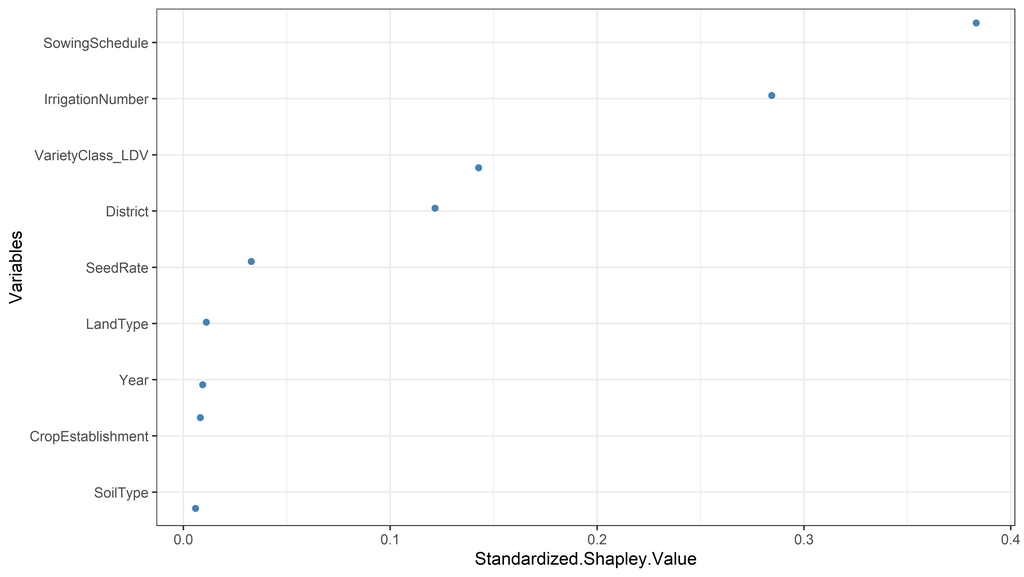

```r
shapleyvaluet=as.data.frame(t(value))
shapleyvaluet=cbind(rownames(shapleyvaluet), data.frame(shapleyvaluet, row.names=NULL))
names(shapleyvaluet)[1]="vars"

library(ggplot2)
shapleyvalueplot=ggplot(shapleyvaluet,aes(x=reorder(vars,Standardized.Shapley.Value),y=Standardized.Shapley.Value))+
  geom_jitter(color="steelblue")+
  coord_flip()+
  labs(x="Variables",y="Standardized.Shapley.Value")
previous_theme <- theme_set(theme_bw())
shapleyvalueplot
```

```r
ggsave("figures/Mean_shapleyvalueplot.png",dpi=300)


# Variance model
y <- CSISA_KVKestim$ols_u^2
x=subset(CSISA_KVKestim, select=c("SowingSchedule","VarietyClass_LDV","SeedRate","CropEstablishment","IrrigationNumber","SoilType","LandType","Year","District"))

value <- shapleyvalue(y,x)

library(kableExtra)
value %>%
  kbl() %>%
  kable_classic(full_width = F, html_font = "Cambria")
```

|  | SowingSchedule | VarietyClass_LDV | SeedRate | CropEstablishment | IrrigationNumber | SoilType | LandType | Year | District |
| --- | --- | --- | --- | --- | --- | --- | --- | --- | --- |
| Shapley Value | 0.0140 | 0.0016 | 0.0017 | 0.0017 | 0.0019 | 0.0021 | 0.0030 | 0.0095 | 0.0478 |
| Standardized Shapley Value | 0.1684 | 0.0188 | 0.0205 | 0.0198 | 0.0230 | 0.0256 | 0.0357 | 0.1141 | 0.5740 |

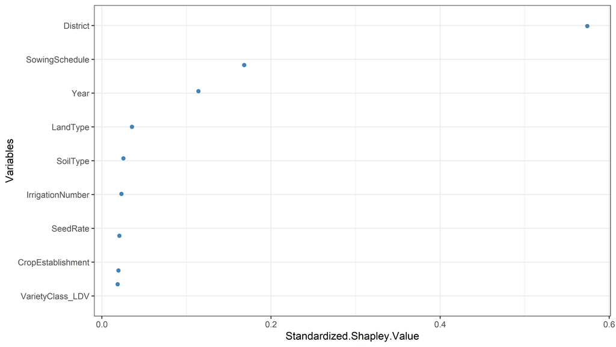

```r
shapleyvaluet=as.data.frame(t(value))
shapleyvaluet=cbind(rownames(shapleyvaluet), data.frame(shapleyvaluet, row.names=NULL))
names(shapleyvaluet)[1]="vars"

library(ggplot2)
shapleyvalueplot=ggplot(shapleyvaluet,aes(x=reorder(vars,Standardized.Shapley.Value),y=Standardized.Shapley.Value))+
  geom_jitter(color="steelblue")+
  coord_flip()+
  labs(x="Variables",y="Standardized.Shapley.Value")
previous_theme <- theme_set(theme_bw())
shapleyvalueplot
```

```r
ggsave("figures/Variance_shapleyvalueplot.png",dpi=300)

# Skewness model
y <- CSISA_KVKestim$ols_u^3
x=subset(CSISA_KVKestim, select=c("SowingSchedule","VarietyClass_LDV","SeedRate","CropEstablishment","IrrigationNumber","SoilType","LandType","Year","District"))

value <- shapleyvalue(y,x)

library(kableExtra)
value %>%
  kbl() %>%
  kable_classic(full_width = F, html_font = "Cambria")
```

|  | SowingSchedule | VarietyClass_LDV | SeedRate | CropEstablishment | IrrigationNumber | SoilType | LandType | Year | District |
| --- | --- | --- | --- | --- | --- | --- | --- | --- | --- |
| Shapley Value | 0.0034 | 0.0002 | 0.0003 | 0.0023 | 0.0002 | 0.0014 | 0.001 | 0.0072 | 0.0025 |
| Standardized Shapley Value | 0.1863 | 0.0089 | 0.0148 | 0.1269 | 0.0088 | 0.0737 | 0.055 | 0.3920 | 0.1336 |

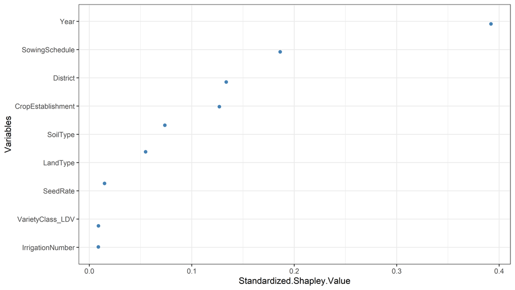

```r
shapleyvaluet=as.data.frame(t(value))
shapleyvaluet=cbind(rownames(shapleyvaluet), data.frame(shapleyvaluet, row.names=NULL))
names(shapleyvaluet)[1]="vars"

library(ggplot2)
shapleyvalueplot=ggplot(shapleyvaluet,aes(x=reorder(vars,Standardized.Shapley.Value),y=Standardized.Shapley.Value))+
  geom_jitter(color="steelblue")+
  coord_flip()+
  labs(x="Variables",y="Standardized.Shapley.Value")
previous_theme <- theme_set(theme_bw())
shapleyvalueplot
```

```r
ggsave("figures/Skewness_shapleyvalueplot.png",dpi=300)

# Kurtosis model
y <- CSISA_KVKestim$ols_u^4
x=subset(CSISA_KVKestim, select=c("SowingSchedule","VarietyClass_LDV","SeedRate","CropEstablishment","IrrigationNumber","SoilType","LandType","Year","District"))

value <- shapleyvalue(y,x)

library(kableExtra)
value %>%
  kbl() %>%
  kable_classic(full_width = F, html_font = "Cambria")
```

|  | SowingSchedule | VarietyClass_LDV | SeedRate | CropEstablishment | IrrigationNumber | SoilType | LandType | Year | District |
| --- | --- | --- | --- | --- | --- | --- | --- | --- | --- |
| Shapley Value | 0.0095 | 0.0032 | 0.0011 | 0.0002 | 0.0020 | 0.0009 | 0.0023 | 0.0079 | 0.0362 |
| Standardized Shapley Value | 0.1503 | 0.0503 | 0.0168 | 0.0032 | 0.0324 | 0.0136 | 0.0359 | 0.1242 | 0.5732 |

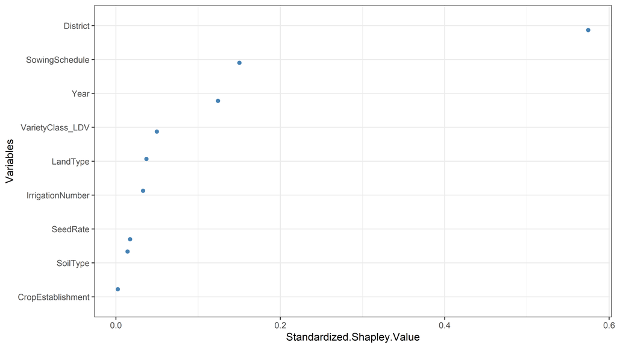

```r
shapleyvaluet=as.data.frame(t(value))
shapleyvaluet=cbind(rownames(shapleyvaluet), data.frame(shapleyvaluet, row.names=NULL))
names(shapleyvaluet)[1]="vars"

library(ggplot2)
shapleyvalueplot=ggplot(shapleyvaluet,aes(x=reorder(vars,Standardized.Shapley.Value),y=Standardized.Shapley.Value))+
  geom_jitter(color="steelblue")+
  coord_flip()+
  labs(x="Variables",y="Standardized.Shapley.Value")
previous_theme <- theme_set(theme_bw())
shapleyvalueplot
```

```r
ggsave("figures/Kurtosis_shapleyvalueplot.png",dpi=300)
```

# 4 Addressing endogeneity using Lewbel (2012) method

When using observational data, there may be endogeneity associated with the choice of the technology.

```r
library(REndo)

hetEr <- hetErrorsIV(GrainYield~SowingSchedule_T1+SowingSchedule_T2+SowingSchedule_T3+SowingSchedule_T4+IrrigationNumber + SeedRate+VarietyClass_LDV |SowingSchedule_T1| IIV(SowingSchedule_T2,SowingSchedule_T3,SowingSchedule_T4,IrrigationNumber,SeedRate,VarietyClass_LDV ), data = CSISA_KVKestim)

summary(hetEr)
```

```
Call:
hetErrorsIV(formula = GrainYield ~ SowingSchedule_T1 + SowingSchedule_T2 +
    SowingSchedule_T3 + SowingSchedule_T4 + IrrigationNumber +
    SeedRate + VarietyClass_LDV | SowingSchedule_T1 | IIV(SowingSchedule_T2,
    SowingSchedule_T3, SowingSchedule_T4, IrrigationNumber, SeedRate,
    VarietyClass_LDV), data = CSISA_KVKestim)

Residuals:
      Min        1Q    Median        3Q       Max
-2.316783 -0.439010  0.003074  0.459840  2.635782

Coefficients:
                   Estimate Std. Error t value Pr(>|t|)
(Intercept)        2.203195   0.153986  14.308  < 2e-16 ***
SowingSchedule_T1  1.328627   0.048057  27.647  < 2e-16 ***
SowingSchedule_T2  1.056724   0.038467  27.471  < 2e-16 ***
SowingSchedule_T3  0.728336   0.035591  20.464  < 2e-16 ***
SowingSchedule_T4  0.309741   0.034204   9.056  < 2e-16 ***
IrrigationNumber   0.541894   0.019000  28.521  < 2e-16 ***
SeedRate          -0.011693   0.002974  -3.931  8.6e-05 ***
VarietyClass_LDV   0.395841   0.027046  14.636  < 2e-16 ***

Diagnostic tests:
                  df1  df2 statistic  p-value
Weak instruments    6 3635  6803.309  < 2e-16 ***
Wu-Hausman          1 3639     2.566    0.109
Sargan              5   NA    54.066 2.03e-10 ***
---
Signif. codes:  0 '***' 0.001 '**' 0.01 '*' 0.05 '.' 0.1 ' ' 1

Residual standard error: 0.6669 on 3640 degrees of freedom
Multiple R-Squared: 0.586,  Adjusted R-squared: 0.5852
Wald test: 730.1 on 7 and 3640 DF,  p-value: < 2.2e-16
```

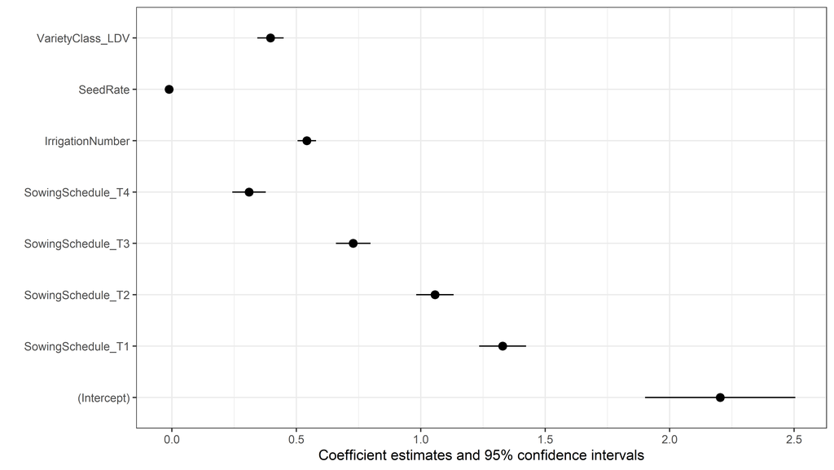

```r
library(modelsummary)

modelplot(hetEr)
```